# Week 8 HW - 624

### Part B

Produce a time plot for the series. How does the plot change as you change $\phi_1$?

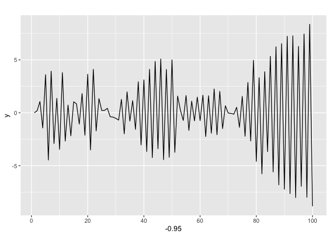

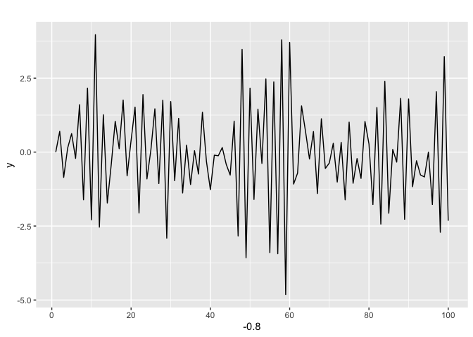

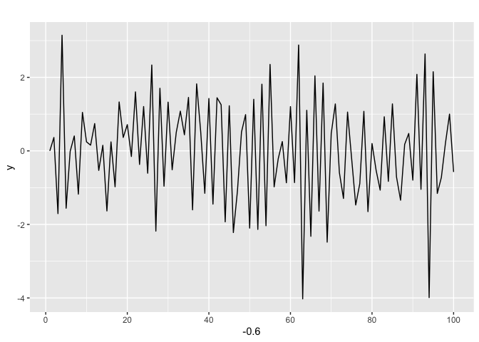

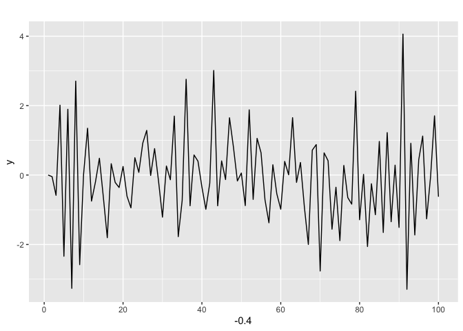

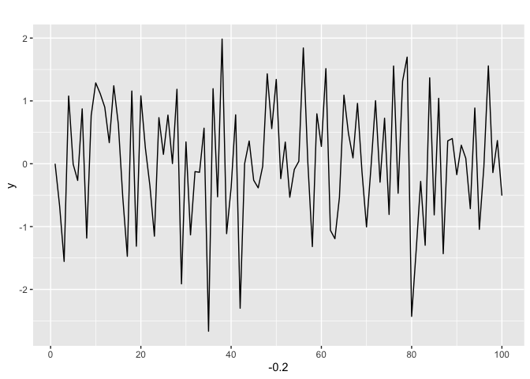

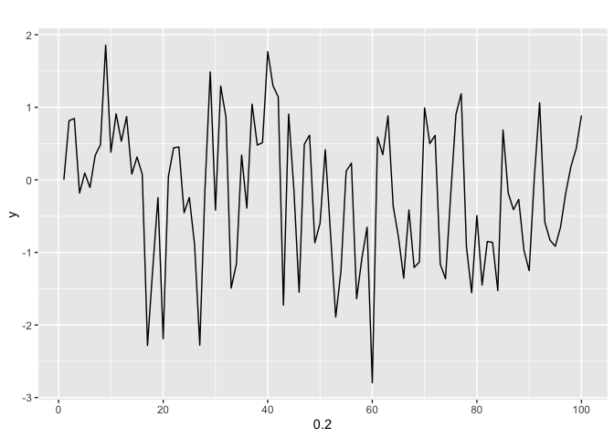

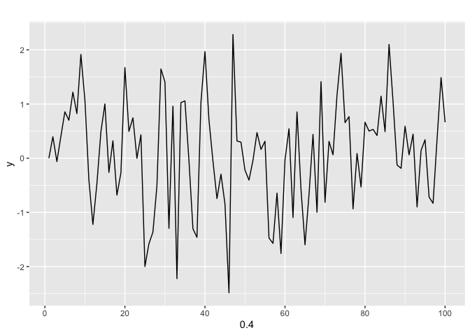

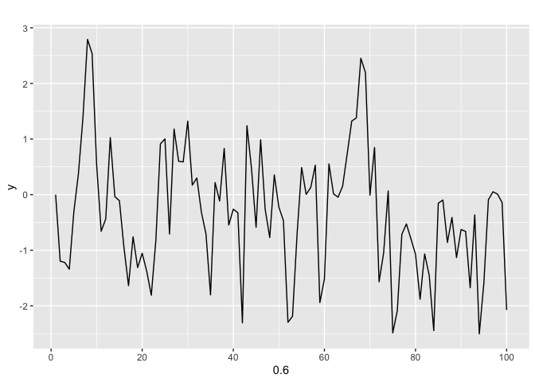

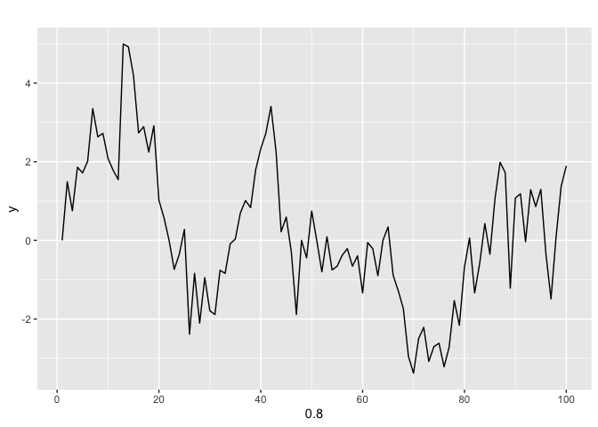

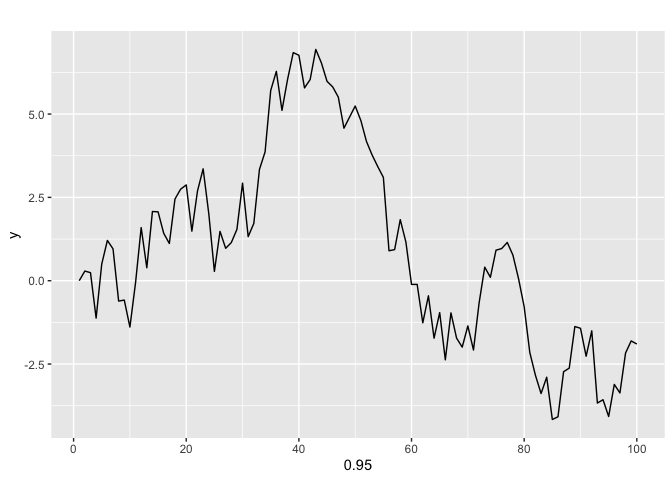

```r
for (i in c(-0.95, -0.8, -0.6, -0.4, -0.2, 0.2, 0.4, 0.6, 0.8, 0.95)) {
    y <- ts(numeric(100))
    e <- rnorm(100)
    for (j in 2:100) {
        y[j] <- i * y[j - 1] + e[j]
    }
    plot1 <- autoplot(y) + xlab(i)
    print(plot1)
}
```

The value chosen for $\phi$ affects how volatile the series is. Negative values (close to -1) force the series to oscillate across the mean nearly every observation, whereas positive values for $\phi$ (close to 1) show much less volatility and are smoother overall.

### Part C

Write your own code to generate data from an MA(1) model with $\theta_1 = 0.6$ and $\sigma^2 = 1$.

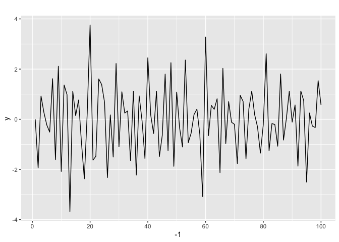

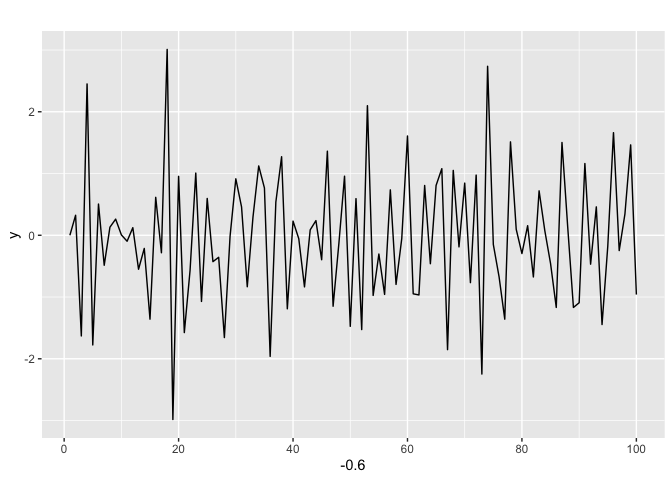

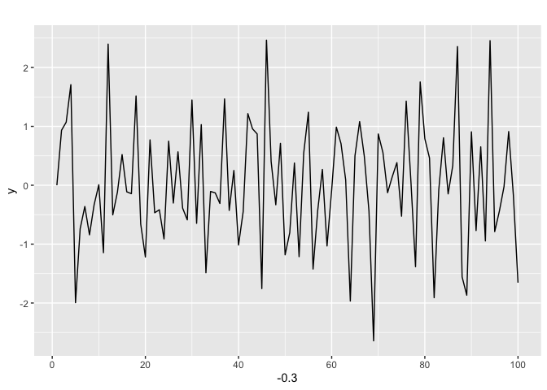

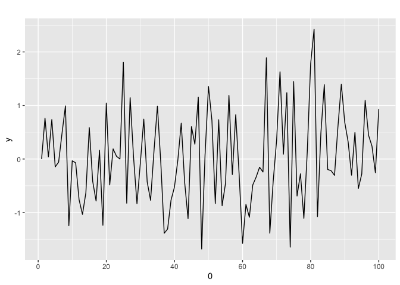

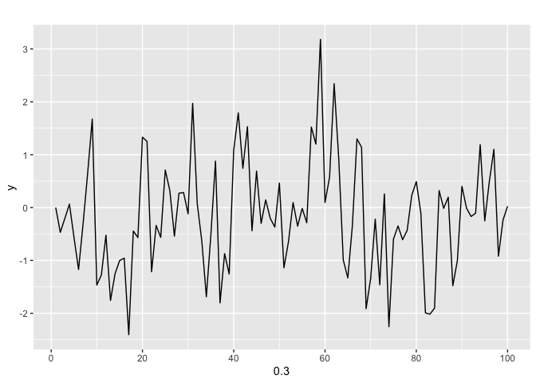

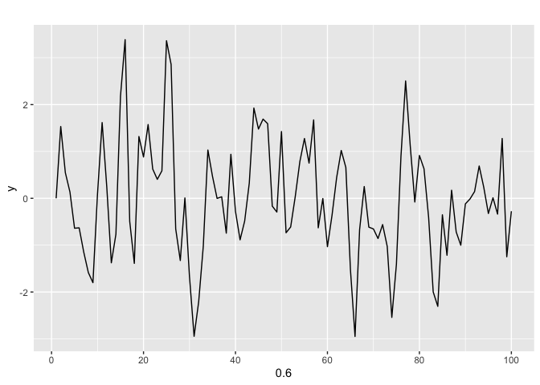

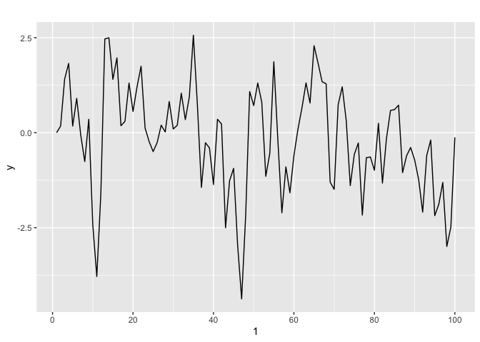

```r
set.seed(42)
for (theta in c(-1, -0.6, -0.3, 0, 0.3, 0.6, 1)) {
  y <- ts(numeric(100))
  e <- rnorm(100)
  for (i in 2:100) {
    y[i] <- theta * e[i - 1] + e[i]
  }
  print(autoplot(y) + xlab(theta))
}
```

### Part D

Produce a time plot for the series. How does the plot change as you change $\theta_1$?

As $\theta$ approaches 1, the time series appears to resemble a random walk. However, as $\theta$ approaches -1, the time series oscillates a lot across the mean with almost every step in the series. For values close to 1, the plot is harder to describe (other than random walk), whereas with $\theta$ close to -1, we see a rapid oscillation.

### Part E

Generate data from an ARMA(1,1) model with $\phi_1 = 0.6, \theta_1 = 0.6$, and $\sigma^2 = 1$.

```r
phi <- 0.6
theta <- 0.6
y_arma <- ts(numeric(100))
e <- rnorm(100)
for (i in 2:100) {
  y_arma[i] <- phi * y_arma[i - 1] + theta * e[i - 1] + e[i]
}
```

### Part F

Generate data from an AR(2) model with $\phi_1 = −0.8$, $\phi_1 = 0.3$, and $\sigma^2 = 1$. (Note that these parameters will give a non-stationary series.)

```r
phi1 <- -0.8
phi2 <- 0.3
y_ar <- ts(numeric(100))
e <- rnorm(100)
y_ar[2] <- y_ar[1] * phi1 + e[2]
for (i in 3:100) {
  y_ar[i] <- phi1 * y_ar[i - 1] + phi2 * y_ar[i - 2] + e[i]
}
```

### Part G

Graph the latter two series and compare them.

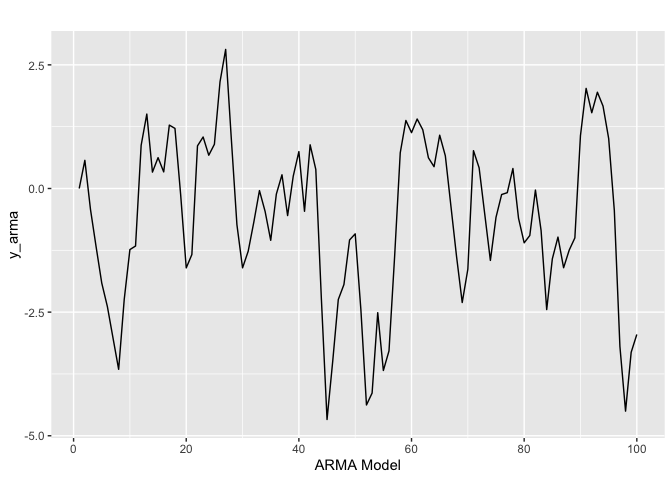

```r
autoplot(y_arma) + xlab('ARMA Model')
```

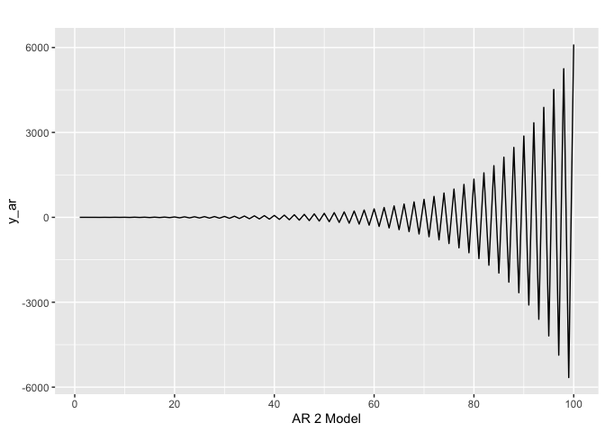

```r
autoplot(y_ar) + xlab('AR 2 Model')
```

# Question HA 8.7

## Question

Consider wmurders , the number of women murdered each year (per 100,000 standard population) in the United States.

1. By studying appropriate graphs of the series in R, find an appropirate ARIMA( ) model for these data.
2. Should you include a constant in the model? Explain.
3. Write this model in terms of the backshift operator.
4. Fit the model using R and examine the residuals. Is the model satisfactory?
5. Forecast three times ahead. Check your forecasts by hand to make sure that you know how they have been calculated.
6. Create a plot of the series with forecasts and prediction intervals for the next three periods shown.
7. Does auto.arima() give the same model you have chosen? If not, which model do you think is better?

## Answer

### Part A

First we inspect the data. These data appear to have one large cycle, but no seasonality. The trends seem a bit piece-wise. We have clear trends up from the 1950s, a relative plateau between 1970 and 1995 and a rapid decrease from there. We will not use a BC transform on this data due to these variations, we doubt much will be gained from the transform.

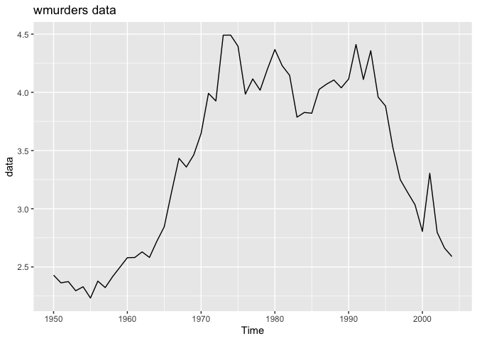

```r
data<- wmurders

autoplot(data) + ggtitle("wmurders data")
```

Next, we will determine some possible value for *p*, *d*, and *q*.

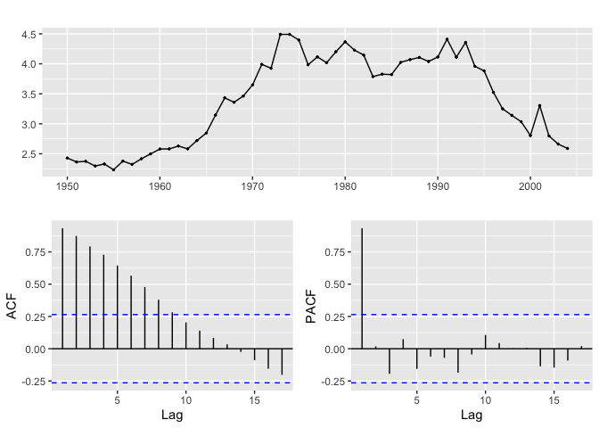

```r
ggtsdisplay(data)
```

Since we have a decaying ACF and a single significant point for PACF, it seems reasonable that *p* is one, a first order AR.

We can also determine that the MA term is likely zero or one as the ACF cutoff is at nine, and slowly tapers which is more the signature of AR.

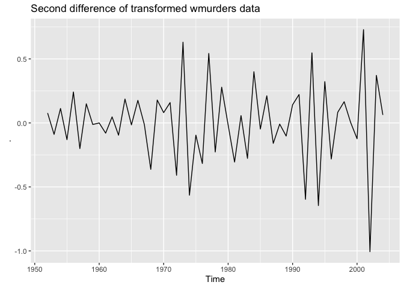

```r
data %>%
  diff() %>%
  diff() %>%
  autoplot() +
    ggtitle("Second difference of transformed wmurders data")
```

### Part B

The differencing for this dataset to stabilize is second order so no constant is needed.

### Part C

$(1 - \phi_1 B) *(1-B)^2y_t = (1-B \phi_1)\epsilon_t$

### Part D

```r
fit <- arima(data, order=c(1,2,1))
fit
```

```
##
## Call:
## arima(x = data, order = c(1, 2, 1))
##
## Coefficients:
##           ar1      ma1
##       -0.2434  -0.8261
## s.e.   0.1553   0.1143
##
## sigma^2 estimated as 0.04457:  log likelihood = 6.44,  aic = -6.88
```

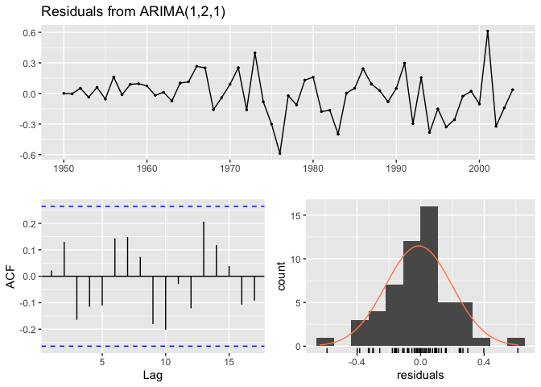

```
##
##  Ljung-Box test
##
## data:  Residuals from ARIMA(1,2,1)
## Q* = 12.419, df = 8, p-value = 0.1335
##
## Model df: 2.   Total lags used: 10
```

```r
checkresiduals(fit)
```

This is a decent model. The ACF plot suggests the residuals are acting like noise and the Ljung-Box test has a p-value of .133, which is above the critical value suggesting the residuals are noise. Other indicators like the distribution looking well centered at zero and nearly-normal points to the conclusion that the residuals are noise.

### Part E and Part F

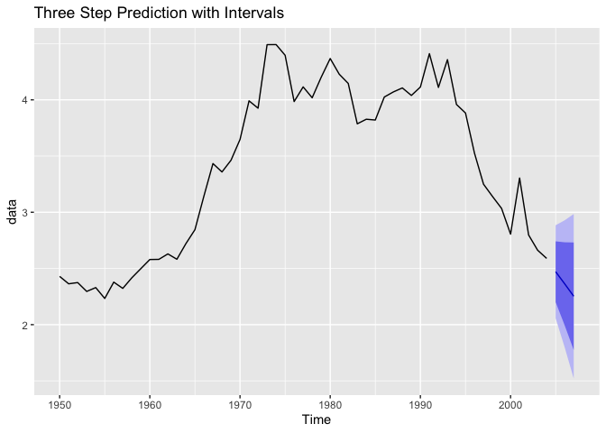

```r
autoplot(forecast(fit,h = 3)) + ggtitle("Three Step Prediction with Intervals")
```

```r
fc<- forecast(fit,h = 3)
fc
```

```
##      Point Forecast    Lo 80    Hi 80    Lo 95    Hi 95
## 2005       2.470660 2.200091 2.741229 2.056861 2.884459
## 2006       2.363106 1.993529 2.732684 1.797886 2.928327
## 2007       2.252833 1.774677 2.730989 1.521557 2.984110
```

```r
y_t <- tail(data,3)
res <- tail(residuals(fit),1)

ar1 <- fit$coef['ar1']
ma1 <- fit$coef['ma1']

y1 <- (1.7566 * y_t[3]) - (0.5132  * y_t[2]) + (ar1 * y_t[1]) + (ma1 * res)
y2 <- 1.7566 * y1[1]- 0.5132  * y_t[3] + ar1 * y_t[2] + ma1 * 0
y3 <- 1.7566 * y2[1] - 0.5132  * y1[1] + ar1 * y_t[3] + ma1 * 0

check_df <- data.frame(cbind(fc$mean, c(y1,y2,y3)))
colnames(check_df) <- c("Model","Manual")
check_df
```

```
##      Model   Manual
## 1 2.470660 2.470527
## 2 2.363106 2.362740
## 3 2.252833 2.252133
```

A consistent result. Using a BC transform on this data would likely make this manual checking process infuriating - sensitivity of log/exponent tranformed numbers is tough.

### Part G

If you run the basic sample space with `auto.arima` we get a consistent result as our analysis.

```r
auto.arima(data)
```

```
## Series: data
## ARIMA(1,2,1)
##
## Coefficients:
##           ar1      ma1
##       -0.2434  -0.8261
## s.e.   0.1553   0.1143
##
## sigma^2 estimated as 0.04632:  log likelihood=6.44
## AIC=-6.88   AICc=-6.39   BIC=-0.97
```

If we transverse the entire space, we find a different model that unlikely to be choosen by intutition.

```r
best_model<- auto.arima(data,
                        seasonal = FALSE,
                        stepwise = FALSE,
                        approximation = FALSE)
best_model
```

```
## Series: data
## ARIMA(0,2,3)
##
## Coefficients:
##           ma1     ma2      ma3
##       -1.0154  0.4324  -0.3217
## s.e.   0.1282  0.2278   0.1737
##
## sigma^2 estimated as 0.04475:  log likelihood=7.77
## AIC=-7.54   AICc=-6.7   BIC=0.35
```

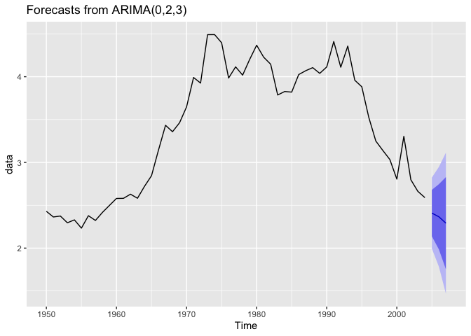

```r
best_model %>% forecast(h=3) %>% autoplot()
```

```r
best_model %>% forecast(h=3)
```

```
##      Point Forecast    Lo 80    Hi 80    Lo 95    Hi 95
## 2005       2.408817 2.137718 2.679916 1.994206 2.823428
## 2006       2.365555 1.985092 2.746018 1.783687 2.947423
## 2007       2.290976 1.753245 2.828706 1.468588 3.113363
```

In practice this model from `auto.arima` appears to predict a little flatter decrease in murders. We feel as though the arima(121) model is better in that it is more explanable to have a single AR term and single MA term rather than three MA terms. The change in AIC is meaningful in terms of simpler models overfit less, but the three step point forecast differences between the (023) and (121) are marginal. Just don’t forecast the (121) too much further.